# Problem 3: Integral equation

# Part 3b: (Verify)

For a choice of N, plot solution you get evaluating (2) using the Trapezoidal method along with an exact solution on the same graph. Plot the error for several values of N to show that your solution is converging to the true solution.

```python
%pylab inline
%matplotlib notebook
import time
import pandas
```

## Accuracy Results when N = 16 and P = 32768

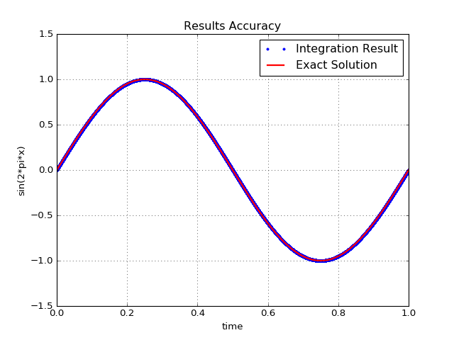

```python
figure()
clf
x = np.genfromtxt('trap3b_16_15.out')
Value = x[:,4]
Samples = x[:,3][1]
t = np.arange(0, (1+1/Samples), 1/Samples) # Matching the dimensions
plot(t,Value, 'b.')
plot(t,sin(2*np.pi*t), 'r-', linewidth=2.0)
xlabel('time')
ylabel('sin(2*pi*x)')
legend(['Integration Result', 'Exact Solution'])
title('Results Accuracy')
grid(True)
show()
```

## Error Plots using different P

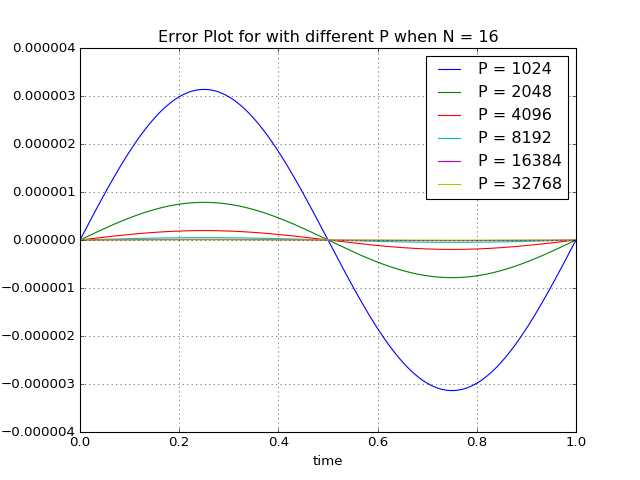

```python
figure()
clf()
file_prefix = 'trap3b_16_'
for i in range (10, 16):
    filename = file_prefix + '{:02d}'.format(i) + '.out'
    x = np.genfromtxt(filename)
    Value = x[:,4]
    Samples = x[:,3][1]
    t = np.arange(0, (1+1/Samples), 1/Samples) # Matching the dimension
    plot(t,Value-sin(2*np.pi*t))
    grid(True)
legend(['P = 1024', 'P = 2048', 'P = 4096', 'P = 8192', 'P = 16384', 'P = 32768'])
xlabel('time')
ylabel('Error')
title('Error Plot for with different P when N = 16')
show()
```

# Part 3c: Scaling results

Show weak scaling, strong scaling and efficiency results for this approach to solving the second order differential equation.

### Strong Scaling

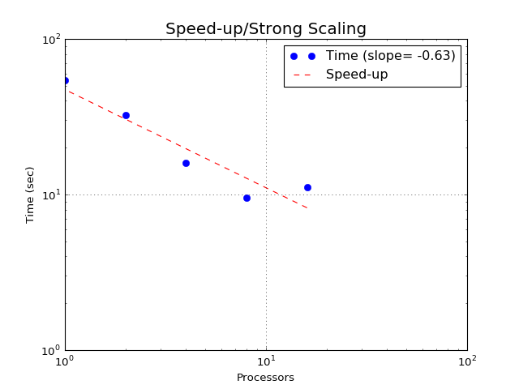

```python
## Choosing P = 32768
figure()
clf()
filename = 'trap3b_time.out'
t = []
p = []
x = np.genfromtxt(filename)
for i in range (0, 5):
    t.append(x[i*6 + 5][2])
    p.append(x[i*6 + 5][0])

loglog(p,t,'b.', markersize=15)
c = polyfit(log(p),log(t),1)
loglog(p,exp(polyval(c,log(p))),'r--')
xlabel('Processors')
ylabel('Time (sec)')
legend(['Time (slope={:6.2f})'.format(c[0]),'Speed-up'])
title('Speed-up/Strong Scaling',fontsize=18)
grid(True)
show()
```

### Weak Scaling

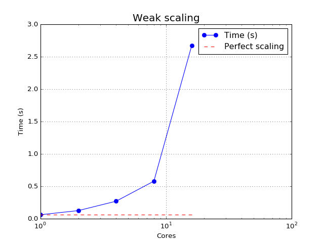

```python
## Choosing P = 16384
figure()
clf()

filename = 'trap3b_time.out'
t = []
p = []
x = np.genfromtxt(filename)
for i in range (0, 5):
    t.append(x[i*6 + 4-i][2])
    p.append(x[i*6 + 4-i][0])

semilogx(p,t,'.-',markersize=15)
semilogx(p,[t[4]]*5,'r--')
title('Weak scaling', fontsize=18)
xlabel('Cores')
ylabel("Time (s)")
legend(['Time (s)','Perfect scaling'])
grid(True)
show()
```

### Efficiency

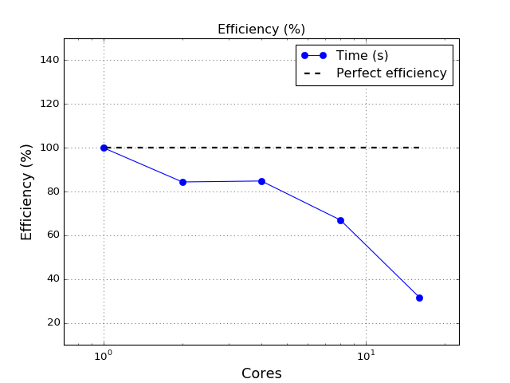

```python
figure()
clf()

filename = 'trap3b_time.out'
t = []
p = []
x = np.genfromtxt(filename)
for i in range (0, 5):
    t.append(x[i*6 + 4][2])
    p.append(x[i*6 + 4][0])

E = [t[4]/(a*b)*100 for a,b in zip(t,p)]
semilogx(p,E,'.-',markersize=15)
semilogx(p,[100]*5,'k--',linewidth=2)
xlabel('Cores',fontsize=16)
ylabel('Efficiency (%)',fontsize=16)
title("Efficiency (%)");
legend(['Time (s)', 'Perfect efficiency'])
xlim([1/sqrt(2), 2**4.5])
ylim([10,150])
grid()
show()
```

# Part 3c: Finite Difference

Compare the error that you get from solving the integral equation with the error you get from solving the Ax = b problem. You should see that the error for the integral solution decreases even for very large N, unlike the solution resulting from inverting the matrix A. To produce the errors for the linear solve, you may use Matlab. Compare the timing results for both approaches as well.

```python
cat Finite_Difference.m
```

[output not shown]

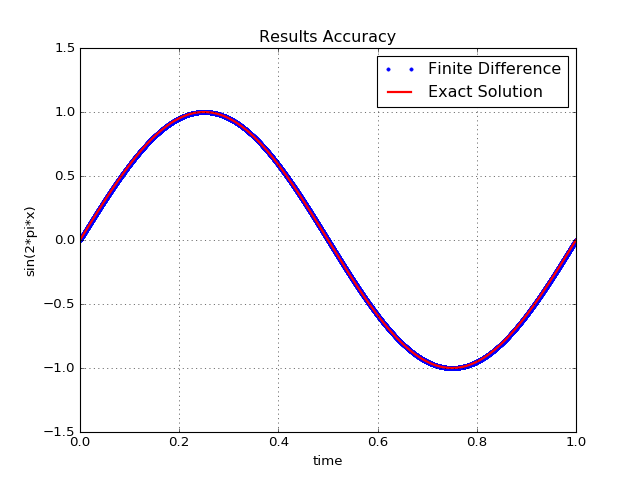

```python
figure()
clf
x = np.genfromtxt('Matlab_Data.txt')
Samples = 2**14
t = np.arange(0, 1, 1/Samples)
plot(t,x, 'b.')
plot(t,sin(2*np.pi*t), 'r-', linewidth=2.0)
xlabel('time')
ylabel('sin(2*pi*x)')
legend(['Finite Difference', 'Exact Solution'])
title('Results Accuracy')
grid(True)
ylim(-1.5, 1.5)
show()
```

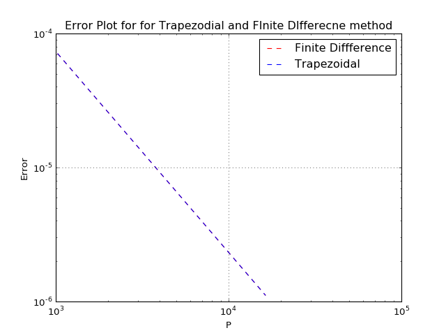

```python
EFiniteDiff = [7.0889e-5, 2.5081e-5, 8.8709e-6, 3.1372e-6, 1.109e-6]

figure()
clf()
N = []
file_prefix = 'Matlab_Data_'
for i in range (10, 15):
    filename = file_prefix + '{:02d}'.format(i) + '.txt'
#     x = np.genfromtxt(filename)
    Samples = 2**i
#     t = np.arange(1/Samples, 1+1/Samples, 1/Samples)
#     EFiniteDiff.append(sqrt(sum((x-sin(2*np.pi*t))**2)))
    N.append(Samples)
E_Trapz = []
for i in range (10, 15):
    filename = 'trap3b_01_' + '{:02d}'.format(i) + '.out'
    x = np.genfromtxt(filename)
    Value = x[:,4]
    Samples = x[:,3][1]
    t = np.arange(0, (1+1/Samples), 1/Samples) # Matching the dimension
    E_Trapz.append(sqrt(sum((Value-sin(2*np.pi*t))**2)))

loglog(N, EFiniteDiff,'r--', label='Finite Diffference')
loglog(N, E_Trapz , 'b--', Markersize = 10,  label='Trapezoidal')
grid(True)
legend()
xlabel('P')
ylabel('Error')
title('Error Plot for for Trapezodial and FInite DIfferecne method')
show()
```

Finite Difference Method was implemented in Matlab. The error from Finite Difference Method is comparable to Trapezoidal till 2^14. For Matrices of size 2^15 or greater, the RAM required by Matlab to create them is insufficient. For larger values of P, the error from Finite Difference method should become larger than Trapezodial Method.

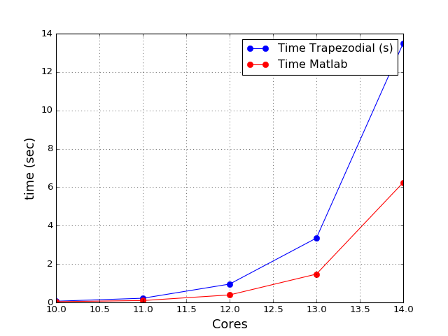

```python
figure()
clf()
t_matlab = [0.037963, 0.096237, 0.389239, 1.474054, 6.245294]
filename = 'trap3b_time.out'
t = []
p = []
x = np.genfromtxt(filename)
for i in range (0, 5):
    t.append(x[i + 24][2])
    p.append(x[i + 24][1])

plot(p,t,'.-',markersize=15)
plot(p,t_matlab,'r.-', markersize=15)
xlabel('Cores',fontsize=16)
ylabel('time (sec)',fontsize=16)
legend(['Time Trapezodial (s)', 'Time Matlab'])
grid()
show()
```

# Part 3e: Simpson’s rule

Develop a fourth order solver by using Simpson’s rule to evaluate the integral equation. How does the scaling for the higher order integral compare to the lower order method?

## Accuracy Results when N = 16 and P = 32768

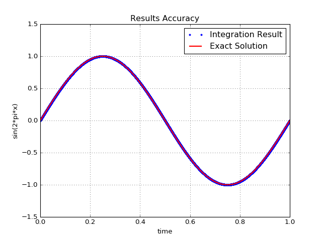

```python
figure()
clf
x = np.genfromtxt('trap3e_16_15.out')
Value = x[:,4]
Samples = x[:,3][1]
t = np.arange(0, (1+1/Samples), 1/Samples) # Matching the dimensions
plot(t,Value, 'b.')
plot(t,sin(2*np.pi*t), 'r-', linewidth=2.0)
xlabel('time')
ylabel('sin(2*pi*x)')
legend(['Integration Result', 'Exact Solution'])
title('Results Accuracy')
ylim([-1.5, 1.5])
grid(True)
show()
```

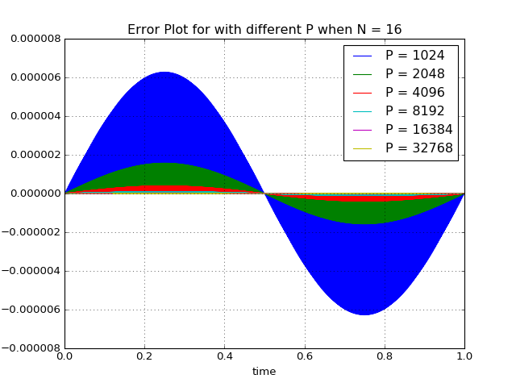

```python
figure()
clf()
file_prefix = 'trap3e_16_'
for i in range (10, 16):
    filename = file_prefix + '{:02d}'.format(i) + '.out'
    x = np.genfromtxt(filename)
    Value = x[:,4]
    Samples = x[:,3][1]
    t = np.arange(0, (1+1/Samples), 1/Samples) # Matching the dimension
    plot(t,Value-sin(2*np.pi*t))
    grid(True)
legend(['P = 1024', 'P = 2048', 'P = 4096', 'P = 8192', 'P = 16384', 'P = 32768'])
xlabel('time')
ylabel('Error')
title('Error Plot for with different P when N = 16')
show()
```

### Strong Scaling

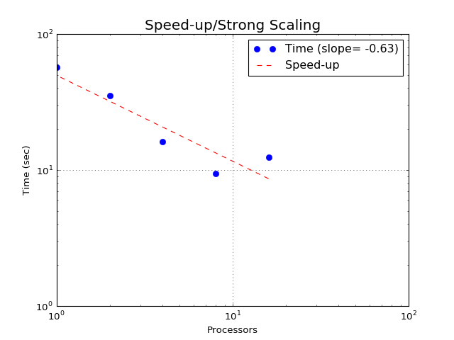

```python
## Choosing P = 32768
figure()
clf()
filename = 'trap3e_time.out'
t = []
p = []
x = np.genfromtxt(filename)
for i in range (0, 5):
    t.append(x[i*6 + 5][2])
    p.append(x[i*6 + 5][0])

loglog(p,t,'b.', markersize=15)
c = polyfit(log(p),log(t),1)
loglog(p,exp(polyval(c,log(p))),'r--')
xlabel('Processors')
ylabel('Time (sec)')
legend(['Time (slope={:6.2f})'.format(c[0]),'Speed-up'])
title('Speed-up/Strong Scaling',fontsize=18)
grid(True)
show()
```

### Weak Scaling

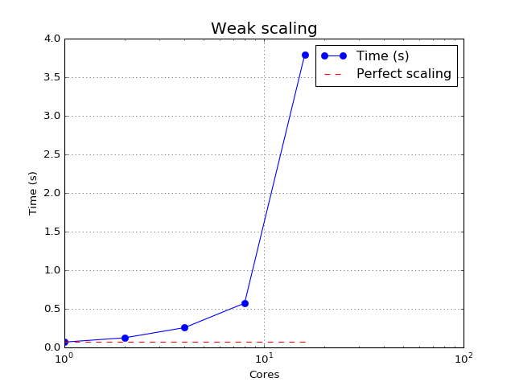

```python
## Choosing P = 16384
figure()
clf()

filename = 'trap3e_time.out'
t = []
p = []
x = np.genfromtxt(filename)
for i in range (0, 5):
    t.append(x[i*6 + 4-i][2])
    p.append(x[i*6 + 4-i][0])

semilogx(p,t,'.-',markersize=15)
semilogx(p,[t[4]]*5,'r--')
title('Weak scaling', fontsize=18)
xlabel('Cores')
ylabel("Time (s)")
legend(['Time (s)','Perfect scaling'])
grid(True)
show()
```

### Efficiency

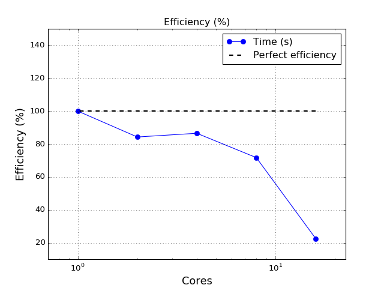

```python
figure()
clf()

filename = 'trap3e_time.out'
t = []
p = []
x = np.genfromtxt(filename)
for i in range (0, 5):
    t.append(x[i*6 + 4][2])
    p.append(x[i*6 + 4][0])

E = [t[4]/(a*b)*100 for a,b in zip(t,p)]
semilogx(p,E,'.-',markersize=15)
semilogx(p,[100]*5,'k--',linewidth=2)
xlabel('Cores',fontsize=16)
ylabel('Efficiency (%)',fontsize=16)
title("Efficiency (%)");
legend(['Time (s)', 'Perfect efficiency'])
xlim([1/sqrt(2), 2**4.5])
ylim([10,150])
grid()
show()
```

### Error Comparison between Simpson Method and Trapezoidal Method

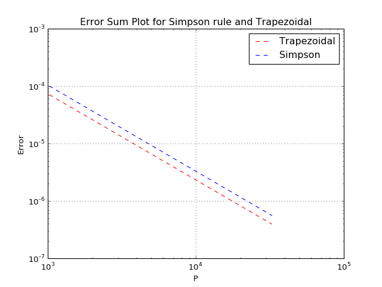

```python
figure()
clf()
#plt.rc('axes', prop_cycle=(cycler('color', ['r', 'g', 'b', 'y', 'k', 'm'])))
E_Trapz = []
E_Simpson = []
P = []
for i in range (10, 16):
    filename = 'trap3b_16_' + '{:02d}'.format(i) + '.out'
    x = np.genfromtxt(filename)
    Value = x[:,4]
    Samples = x[:,3][1]
    t = np.arange(0, (1+1/Samples), 1/Samples) # Matching the dimension
    E_Trapz.append(sqrt(sum((Value-sin(2*np.pi*t))**2)))
    #loglog(Samples,sum(Value-sin(2*np.pi*t)), 'b.', Markersize = 10,  label='Trapz')
for i in range (10, 16):
    filename = 'trap3e_16_' + '{:02d}'.format(i) + '.out'
    x = np.genfromtxt(filename)
    Value = x[:,4]
    Samples = x[:,3][1]
    t = np.arange(0, (1+1/Samples), 1/Samples) # Matching the dimension
    E_Simpson.append(sqrt(sum((Value-sin(2*np.pi*t))**2)))
    P.append(Samples)
loglog(P, E_Trapz , 'r--', Markersize = 10,  label='Trapezoidal')
loglog(P, E_Simpson , 'b--', Markersize = 10,  label='Simpson')
grid(True)
legend()
xlabel('P')
ylabel('Error')
title('Error Sum Plot for Simpson rule and Trapezoidal')
show()
```

# Green's Theorem

```python
%cat p3b.c
```

```
#include "demo7.h"
#include <demo_util.h>
#include <mpi.h>
#include <math.h>

#define ROOT_PROCESSOR 0
/* Function prototype*/
double trapz(double low, double high, double x, int n, double width);

/* Integrate this over [0,1] */
double f(double x)
{
    double fx;
    fx = -(2*M_PI)*(2*M_PI)*sin(2*M_PI*x);
    return fx;
}

double select_part(double x, double limit)
{
	double temp;
	if(limit < x) {
		temp = (x-1)*limit*f(limit);
	} else {
		temp = x*(limit-1)*f(limit);
	}
	return temp;
}

double trapz(double low, double high, double x, int n, double width)
{
	int i;
	double lowLimit = low;
    double integral = 0; // hold the value of integration
	integral = (select_part(x,low) + select_part(x, high)) / 2.0;

	for (i = 1; i < n; i++)
	{
		lowLimit = lowLimit + width;
		integral += select_part(x, lowLimit);
	}
```

[output cut: 74 more lines]

```
		xj = w_local*j;
	    /* Every processor now knows its range and number of panels */
    	/* Apply trapezoidal rule (for loop) */
	    double integral_local = 0;
		integral_local = trapz(range[0], range[1], xj, n_local, w_local);

		/* Call MPI_Reduce to get final integral */
		double integral_global = 0;
		MPI_Reduce((void *)&integral_local, (void *)&integral_global, 1, MPI_DOUBLE, MPI_SUM, (int)ROOT_PROCESSOR, MPI_COMM_WORLD);
		/* Node 0 prints the results - print_global() */
		print_global("%10d    %.16f\n", n_global, integral_global);
	}

    MPI_Finalize();
}
```

# Simpson Rule

```python
%cat p3e.c
```

```
#include "demo7.h"
#include <demo_util.h>
#include <mpi.h>
#include <math.h>

#define ROOT_PROCESSOR 0
/* Function prototype*/
double simpson(double low, double high, double x, int n, double width);

/* Integrate this over [0,1] */
double f(double x)
{
    double fx;
    fx = -(2*M_PI)*(2*M_PI)*sin(2*M_PI*x);
    return fx;
}

double select_part(double x, double limit)
{
	double temp;
	if(limit < x) {
		temp = (x-1)*limit*f(limit);
	} else {
		temp = x*(limit-1)*f(limit);
	}
	return temp;
}

double simpson(double low, double high, double x, int n, double width)
{
	int i;
	double lowLimit = low;
    double integral = 0; // hold the value of integration
	integral = (select_part(x,low) + 4*select_part(x,low+width) + select_part(x, high));
	lowLimit = lowLimit + width; // adding the first integral

	for (i = 2; i < n; i+=2)
	{
		lowLimit = lowLimit + width;
		integral += 2*select_part(x, lowLimit);
```

[output cut: 70 more lines]

```
		xj = w_local*j;
	    /* Every processor now knows its range and number of panels */
    	/* Apply trapezoidal rule (for loop) */
	    double integral_local = 0;
		integral_local = simpson(range[0], range[1], xj, n_local, w_local);

		/* Call MPI_Reduce to get final integral */
		double integral_global = 0;
		MPI_Reduce((void *)&integral_local, (void *)&integral_global, 1, MPI_DOUBLE, MPI_SUM, (int)ROOT_PROCESSOR, MPI_COMM_WORLD);
		/* Node 0 prints the results - print_global() */
		print_global("%10d    %.16f\n", n_global, integral_global);
	}

    MPI_Finalize();
}
```